# Initial Korean covid 19

Jennifer Contreras

November 12th 2026

Data are from the Patient_Info dataset from South Korea 1 Jan to 1 May 2020. These data were retrieved from a downloadable zip file from kaggle.

Some of the data were uncoded for sex - sex must be just male or female. 77 of the data entries were coded sex as blank, so we omit these. State of a patient must be died or alive - we adjust that as well. This is done in the mutate function.

Variables of interest: sex, result

Research Question: - Is dying independent of sex?

# Introduction

Based of the dataset from the Patient_Info dataset from South Korea, is death independent from sex concerning Covid-19?

$H_0$: There is no relationship between Covid-19 deaths and the sex of the patient in South Korea from January to May of 2020.

$H_A$: There is a relationship between Covid-19 deaths and the sex of the patient in South Korea from January to May of 2020.

## Methods

Deaths from Covid-19 or the results is categorical.

Sex is categorical.

# Data Results

## Graphical results

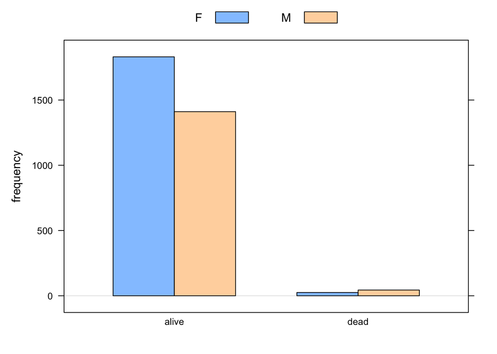

```r
barchartGC(~result + Sex,data=kRdata)
```

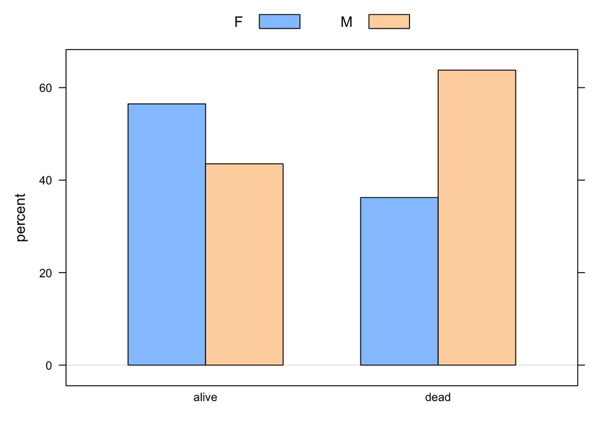

```r
barchartGC(~result + Sex,data=kRdata, type="percent")
```

According to this bar chart, there was a higher percentage of females that survived Covid-19 than men and a higher percentage of men that died from Covid-19 than women.

## Numerical results

```r
table1 <- xtabs(~result + Sex, data=kRdata)
rowPerc(table1)
```

```
##        Sex
## result    F   M Total
##   alive  56  44   100
##   dead   36  64   100
```

```r
colPerc(table1)
```

```
##        Sex
## result      F   M
##   alive  98.7  97
##   dead    1.4   3
##   Total 100.0 100
```

According to this table, there appeared to be higher deaths among men than women. Women have percentages of higher survivial rates concerning Covid-19.

## Inferential results

```r
chisq.test(table1)
```

```
##
##  Pearson's Chi-squared test with Yates' continuity correction
##
## data:  table1
## X-squared = 10, df = 1, p-value = 0.001
```

```r
chisqtestGC(table1)
```

```
## Pearson's Chi-squared test with Yates' continuity correction
##
## Observed Counts:
##        Sex
## result     F    M
##   alive 1831 1411
##   dead    25   44
##
## Counts Expected by Null:
##        Sex
## result     F    M
##   alive 1817 1425
##   dead    39   30
##
## Contributions to the chi-square statistic:
##        Sex
## result     F    M
##   alive 0.10 0.13
##   dead  4.84 6.17
##
##
## Chi-Square Statistic = 10
## Degrees of Freedom of the table = 1
## P-Value = 0.0012
```

```r
fisher.test(table1)
```

```
##
##  Fisher's Exact Test for Count Data
##
## data:  table1
## p-value = 9e-04
## alternative hypothesis: true odds ratio is not equal to 1
## 95 percent confidence interval:
##  1.4 3.9
## sample estimates:
## odds ratio
##        2.3
```

The p-value is 0.001 which is less than 0.05. This means we will reject the null hypothesis and that we conclude that there is a relationship between sex and death from Covid-19 in South Korea from January to May in 2020.

# Conclusions

In South Korea from January to May of 2020, was death from Covid-19 independent from sex?

Based off of the information gathered from tests and plots performed, we reject the null hypothesis as the p-value resulted in the value of 0.001 which is below 0.05. We can conclude that there is a relationship between deaths from Covid-19 and sex in South Korea. The data displayed that there were higher mortality percentages for men and lower mortality percentages for women.